# INFORME DE ANÁLISIS DE GRANDES VOLUMENES DE DATOS

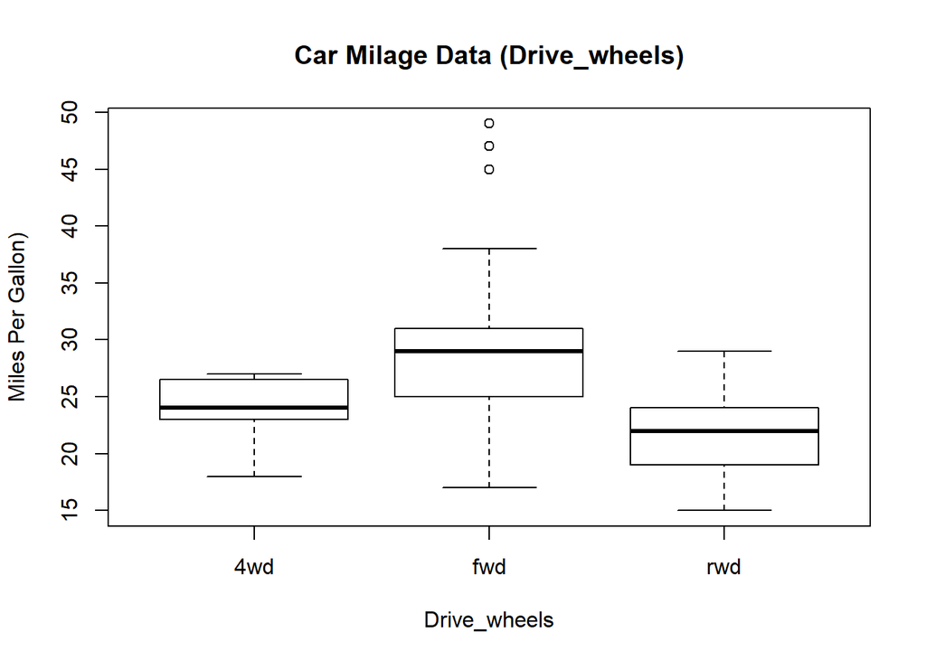

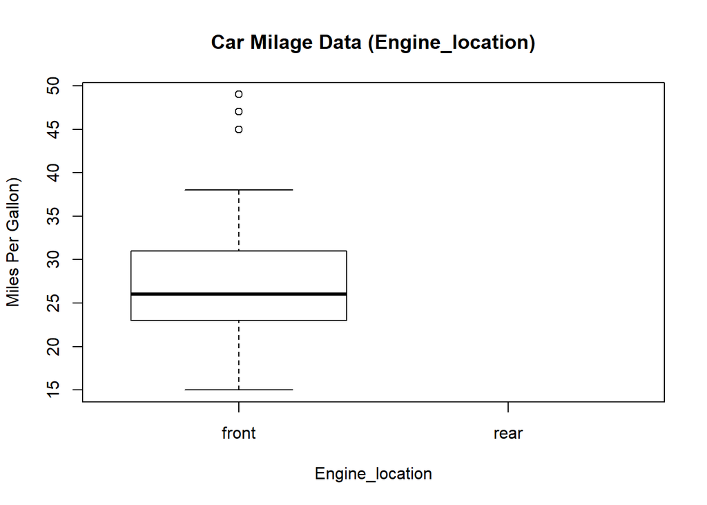

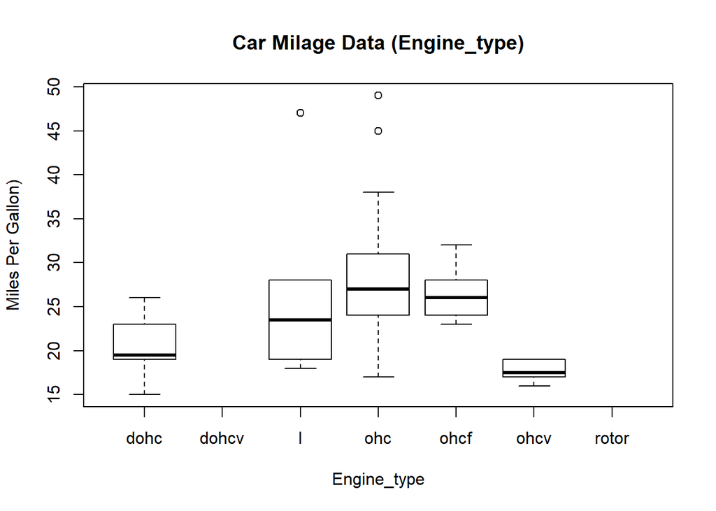

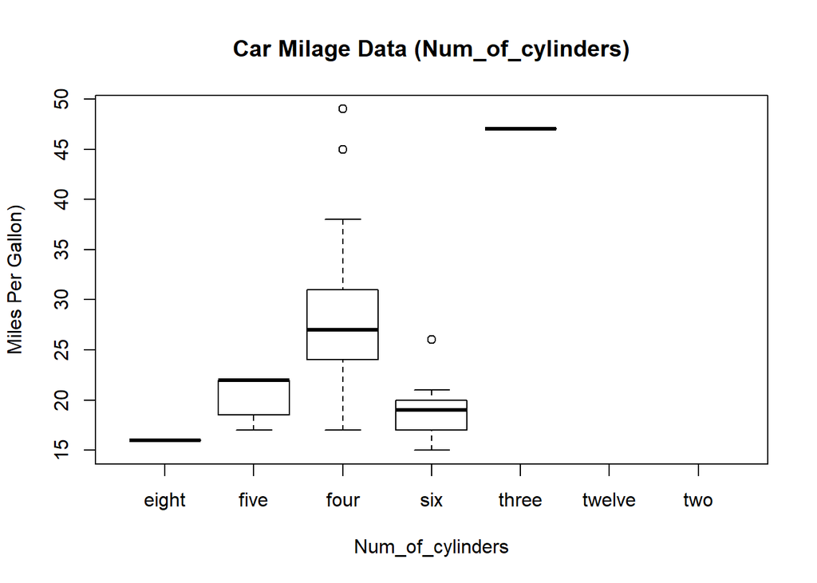

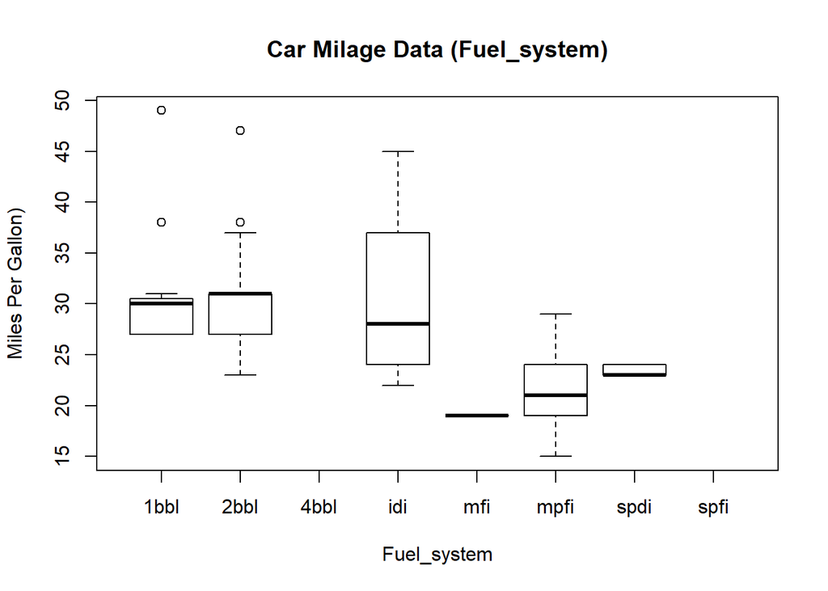

### Analizamos los datos de cara a justificar y/o explicar la selección de tres factores que influyan en el consumo

#### Coeficiente de correlación de las variables City_mpg y Wheel_base

```
## [1] -0.5806572
```

#### Coeficiente de correlación de las variables City_mpg y Length

```
## [1] -0.7245444
```

#### Coeficiente de correlación de las variables City_mpg y Width

```
## [1] -0.6666844
```

#### Coeficiente de correlación de las variables City_mpg y Height

```
## [1] -0.1997375
```

#### Coeficiente de correlación de las variables City_mpg y Curb_weight

```
## [1] -0.7621552
```

#### Coeficiente de correlación de las variables City_mpg y Engine_size

```
## [1] -0.6991393
```

#### Coeficiente de correlación de las variables City_mpg y Bore

```
## [1] -0.5943196
```

#### Coeficiente de correlación de las variables City_mpg y Stroke

```
## [1] -0.02584164
```

#### Coeficiente de correlación de las variables City_mpg y Compression_ratio

```
## [1] 0.2783316
```

#### Coeficiente de correlación de las variables City_mpg y Horsepower

```
## [1] 0.4589688
```

#### Coeficiente de correlación de las variables City_mpg y Peak_rpm

```
## [1] -0.04813613
```

#### Coeficiente de correlación de las variables City_mpg y Price

```
## [1] 0.3857882
```

#### Coeficiente de correlación de las variables ciudad City_mpg y Highway_mpg

```
## [1] 0.9719988
```

### Tabla de valor del coeficiente de correlación de cada una de las variables numéricas

[output not shown]

### Resultado de la exploración y análisis de los Datos

De la exploración y análisis realizado se identifica que las variable Length, Width, Height,Curb_weight, Engine_size y Bore tienen correlación negativa con la variable (City_mpg): Se da cuando una variable aumenta la otra disminuye. Se identifica que las variables Horsepower y Price tienen correlación positiva con la variable (City_mpg): Se da cuando la variable independiente aumenta y, la variable dependiente también aumenta.

### b.Construya, interprete y evalúe un modelo de regresión lineal para el consumo (mpg). A la hora de construir el modelo tenga en cuenta la influencia de las variables.

Del literal a, donde analizamos las gráficas y posteriormente los coeficientes de correlación de todas las variables con la variable City_mpg, vemos que la variable consumo en la ciudad " Highway_mpg " tine mayor correlación e influencia sobre la variable City_mpg. Primeramente construimos el modelo todas las variables para confirmar lo expuesto anteriormente para y obtener el modelo final.

#### Construcción y resumen del Modelo con todas la variables

```r
modelo <- lm(City_mpg ~ Curb_weight+Wheel_base+ Length+Width+Height+Engine_type+ Engine_size+Bore+Stroke+Compression_ratio+Horsepower+Peak_rpm+Highway_mpg+Price,data = dfvehiculos)
summary(modelo)
```

```
##
## Call:
## lm(formula = City_mpg ~ Curb_weight + Wheel_base + Length + Width +
##     Height + Engine_type + Engine_size + Bore + Stroke + Compression_ratio +
##     Horsepower + Peak_rpm + Highway_mpg + Price, data = dfvehiculos)
##
## Residuals:
##     Min      1Q  Median      3Q     Max
## -3.0948 -0.8375 -0.0550  0.5543  3.6180
##
## Coefficients:
##                     Estimate Std. Error t value Pr(>|t|)
## (Intercept)       -2.4224127  7.9637578  -0.304 0.761440
## Curb_weight        0.0001157  0.0009166   0.126 0.899722
## Wheel_base         0.1081575  0.0532194   2.032 0.044001 *
## Length            -0.1003183  0.0257287  -3.899 0.000149 ***
## Width              0.0870849  0.1301175   0.669 0.504412
## Height             0.0774643  0.0689698   1.123 0.263277
## Engine_typel      -1.2477008  0.8581544  -1.454 0.148187
## Engine_typeohc    -0.9714685  0.5811600  -1.672 0.096821 .
## Engine_typeohcf    0.7444491  0.8261766   0.901 0.369084
## Engine_typeohcv   -0.7985902  0.7514184  -1.063 0.289700
## Engine_size       -0.0052106  0.0130974  -0.398 0.691356
## Bore              -0.0349725  0.0192120  -1.820 0.070827 .
## Stroke             0.0090289  0.0190184   0.475 0.635702
## Compression_ratio  0.1265671  0.0420945   3.007 0.003127 **
## Horsepower        -0.0012958  0.0077231  -0.168 0.866995
## Peak_rpm          -0.0192322  0.0306232  -0.628 0.531003
## Highway_mpg        0.8303459  0.0385607  21.533  < 2e-16 ***
## Price             -0.0027880  0.0022779  -1.224 0.223016
## ---
## Signif. codes:  0 '***' 0.001 '**' 0.01 '*' 0.05 '.' 0.1 ' ' 1
##
## Residual standard error: 1.269 on 141 degrees of freedom
## Multiple R-squared:  0.9613, Adjusted R-squared:  0.9567
## F-statistic: 206.3 on 17 and 141 DF,  p-value: < 2.2e-16
```

#### Calculo de AIC para diferentes combinaciones de modelos

```
## Start:  AIC=92.64
## City_mpg ~ Curb_weight + Wheel_base + Length + Width + Height +
##     Engine_type + Engine_size + Bore + Stroke + Compression_ratio +
##     Horsepower + Peak_rpm + Highway_mpg + Price
##
##                     Df Sum of Sq    RSS    AIC
## - Curb_weight        1      0.03 227.06  90.66
## - Horsepower         1      0.05 227.08  90.67
## - Engine_size        1      0.25 227.29  90.82
## - Stroke             1      0.36 227.40  90.89
## - Peak_rpm           1      0.64 227.67  91.08
## - Width              1      0.72 227.76  91.14
## - Height             1      2.03 229.07  92.05
## - Price              1      2.41 229.45  92.32
## <none>                           227.04  92.64
## - Bore               1      5.34 232.37  94.33
## - Wheel_base         1      6.65 233.69  95.23
## - Engine_type        4     20.38 247.42  98.31
## - Compression_ratio  1     14.56 241.59 100.52
## - Length             1     24.48 251.52 106.92
## - Highway_mpg        1    746.63 973.67 322.13
##
## Step:  AIC=90.66
## City_mpg ~ Wheel_base + Length + Width + Height + Engine_type +
##     Engine_size + Bore + Stroke + Compression_ratio + Horsepower +
##     Peak_rpm + Highway_mpg + Price
##
##                     Df Sum of Sq     RSS    AIC
## - Horsepower         1      0.05  227.12  88.69
## - Engine_size        1      0.26  227.32  88.84
## - Stroke             1      0.34  227.40  88.89
## - Peak_rpm           1      0.62  227.68  89.09
## - Width              1      0.81  227.87  89.22
## - Height             1      2.33  229.39  90.28
## - Price              1      2.42  229.48  90.34
## <none>                            227.06  90.66
## - Bore               1      5.35  232.41  92.36
## + Curb_weight        1      0.03  227.04  92.64
## - Wheel_base         1      6.63  233.69  93.23
## - Engine_type        4     20.69  247.75  96.52
```

[output cut: 137 more lines]

```
## <none>                            233.20  80.90
## + Price              1      2.39  230.81  81.26
## + Height             1      2.15  231.05  81.43
## + Peak_rpm           1      0.36  232.84  82.65
## + Engine_size        1      0.12  233.09  82.82
## + Width              1      0.08  233.12  82.84
## + Curb_weight        1      0.07  233.13  82.85
## + Stroke             1      0.01  233.19  82.89
## + Horsepower         1      0.00  233.20  82.90
## - Bore               1      8.19  241.39  84.39
## - Wheel_base         1     12.64  245.84  87.29
## - Engine_type        4     24.97  258.18  89.07
## - Length             1     22.10  255.30  93.29
## - Compression_ratio  1     30.05  263.25  98.17
## - Highway_mpg        1   1234.90 1468.10 371.43
```

```
##
## Call:
## lm(formula = City_mpg ~ Wheel_base + Length + Engine_type + Bore +
##     Compression_ratio + Highway_mpg, data = dfvehiculos)
##
## Coefficients:
##       (Intercept)         Wheel_base             Length       Engine_typel
##           1.41820            0.13063           -0.08429           -0.71936
##    Engine_typeohc    Engine_typeohcf    Engine_typeohcv               Bore
##          -0.64815            1.09388           -0.64993           -0.03827
## Compression_ratio        Highway_mpg
##           0.14203            0.82808
```

#### Obtención del Modelo.

El modelo con todas las variables introducidas como predictores tiene un R2 alto (0.9613), es capaz de explicar el 96% de la variabilidad observada en el consumo de un vehículo. El p-value del modelo es significativo (0.0000000000000002), tiende a cero, por lo que se puede aceptar que el modelo no es por azar, al menos uno de los coeficientes parciales de regresión es distinto de 0. Muchos de ellos no son significativos, lo que es un indicativo de que no podrían contribuir al modelo.

#### Resumen del modelo final.

```
##
## Call:
## lm(formula = dfvehiculos$City_mpg ~ dfvehiculos$Highway_mpg)
##
## Coefficients:
##             (Intercept)  dfvehiculos$Highway_mpg
##                 -2.9135                   0.9175
```

#### Formula del modelo final.

```
 Citympg=-2.9135+0.9175*Highway_mpg
```

#### Evaluación del modelo.

Antes de usar Citympg=-2.9135+0.9175*Highway_mpg para predecir la cantidad de combustible consumido en base a la consumo en la carretera (Highway_mpg), hay que asegurarse de que este modelo sea estadísticamente significativo:  
• Existe una relación estadísticamente significativa entre el predictor y la variable resultado  
• El modelo construido se ajusta bien a los datos.

#### Resumen estadístico del modelo.

```
##
## Call:
## lm(formula = dfvehiculos$City_mpg ~ dfvehiculos$Highway_mpg)
##
## Residuals:
##     Min      1Q  Median      3Q     Max
## -2.8594 -0.9521 -0.2820  0.7180  4.8107
##
## Coefficients:
##                         Estimate Std. Error t value Pr(>|t|)
## (Intercept)              -2.9135     0.5793   -5.03 1.33e-06 ***
## dfvehiculos$Highway_mpg   0.9175     0.0177   51.83  < 2e-16 ***
## ---
## Signif. codes:  0 '***' 0.001 '**' 0.01 '*' 0.05 '.' 0.1 ' ' 1
##
## Residual standard error: 1.437 on 157 degrees of freedom
## Multiple R-squared:  0.9448, Adjusted R-squared:  0.9444
## F-statistic:  2686 on 1 and 157 DF,  p-value: < 2.2e-16
```

#### Intervalos de confianza.

```
##                                5 %       95 %
## (Intercept)             -3.8719998 -1.9550922
## dfvehiculos$Highway_mpg  0.8882257  0.9468082
```

#### Error Estándar Residual (RSE)

• RSE = 1.43, lo que significa que los valores de consumo de combustible observados se desvían de la línea de regresión unas 1.43 unidades en promedio.  
• Decidir si un RSE de 1.43 UD es o no un error de predicción aceptable, es subjetivo y depende del contexto del problema. Para ello calculamos el porcentaje de error.

#### Error porcentual

```
## [1] 5.419263
```

### c. Construya, interprete y evalúe un modelo de regresión logística que ayude a determinar la probabilidad de adquirir un vehículo de gasolina (fuel-type).

#### Análisis Preliminar para identificar las variables apropiadas para definir el modelo

#### Visión general del conjunto de datos

```
## Observations: 159
## Variables: 26
## $ Symboling         <int> 2, 2, 1, 1, 2, 0, 0, 0, 2, 1, 0, 1, 1, 1, 1, 1, 1...
## $ Normalized_losses <fct> 164, 164, 158, 158, 192, 192, 188, 188, 121, 98, ...
## $ Make              <fct> audi, audi, audi, audi, bmw, bmw, bmw, bmw, chevr...
## $ Fuel_type         <fct> gas, gas, gas, gas, gas, gas, gas, gas, gas, gas,...
## $ Aspiration        <fct> std, std, std, turbo, std, std, std, std, std, st...
## $ Num_of_doors      <fct> four, four, four, four, two, four, two, four, two...
## $ Body_style        <fct> sedan, sedan, sedan, sedan, sedan, sedan, sedan, ...
## $ Drive_wheels      <fct> fwd, 4wd, fwd, fwd, rwd, rwd, rwd, rwd, fwd, fwd,...
## $ Engine_location   <fct> front, front, front, front, front, front, front, ...
## $ Wheel_base        <dbl> 99.8, 99.4, 105.8, 105.8, 101.2, 101.2, 101.2, 10...
## $ Length            <dbl> 176.6, 176.6, 192.7, 192.7, 176.8, 176.8, 176.8, ...
## $ Width             <dbl> 66.2, 66.4, 71.4, 71.4, 64.8, 64.8, 64.8, 64.8, 6...
## $ Height            <dbl> 54.3, 54.3, 55.7, 55.9, 54.3, 54.3, 54.3, 54.3, 5...
## $ Curb_weight       <int> 2337, 2824, 2844, 3086, 2395, 2395, 2710, 2765, 1...
## $ Engine_type       <fct> ohc, ohc, ohc, ohc, ohc, ohc, ohc, ohc, l, ohc, o...
## $ Num_of_cylinders  <fct> four, five, five, five, four, four, six, six, thr...
## $ Engine_size       <int> 109, 136, 136, 131, 108, 108, 164, 164, 61, 90, 9...
## $ Fuel_system       <fct> mpfi, mpfi, mpfi, mpfi, mpfi, mpfi, mpfi, mpfi, 2...
## $ Bore              <dbl> 15, 15, 15, 12, 26, 26, 18, 18, 4, 9, 9, 6, 6, 9,...
## $ Stroke            <dbl> 26, 26, 26, 26, 8, 8, 19, 19, 11, 15, 15, 21, 21,...
## $ Compression_ratio <dbl> 10.00, 8.00, 8.50, 8.30, 8.80, 8.80, 9.00, 9.00, ...
## $ Horsepower        <dbl> 4, 10, 6, 17, 3, 3, 13, 13, 36, 46, 46, 44, 44, 4...
## $ Peak_rpm          <dbl> 18, 18, 18, 18, 21, 21, 4, 4, 13, 17, 17, 18, 18,...
## $ City_mpg          <int> 24, 18, 19, 17, 23, 23, 21, 21, 47, 38, 38, 37, 3...
## $ Highway_mpg       <int> 30, 22, 25, 20, 29, 29, 28, 28, 53, 43, 43, 41, 3...
## $ Price             <dbl> 38, 63, 65, 83, 51, 60, 77, 78, 103, 113, 119, 10...
```

Al realizar el análisis general preliminar de los datos se identifica que existen 26 variables, 15 numéricas y 11 de tipo factor, entre ellas esta Fuel_type que es nuestra variable a predecir o target.

#### Resumen estadístico y gráficas de las distribuciones de las variables

Data summary

| Name | dfvehiculos |
| --- | --- |
| Number of rows | 159 |
| Number of columns | 26 |
| _______________________ |  |
| Column type frequency: |  |
| factor | 11 |
| numeric | 15 |
| ________________________ |  |
| Group variables | None |

**Variable type: factor**

| skim_variable | n_missing | complete_rate | ordered | n_unique | top_counts |
| --- | --- | --- | --- | --- | --- |
| Normalized_losses | 0 | 1 | FALSE | 51 | 161: 11, 91: 8, 104: 6, 128: 6 |
| Make | 0 | 1 | FALSE | 18 | toy: 31, nis: 18, hon: 13, sub: 12 |
| Fuel_type | 0 | 1 | FALSE | 2 | gas: 144, die: 15 |
| Aspiration | 0 | 1 | FALSE | 2 | std: 132, tur: 27 |
| Num_of_doors | 0 | 1 | FALSE | 2 | fou: 95, two: 64, ?: 0 |
| Body_style | 0 | 1 | FALSE | 5 | sed: 79, hat: 56, wag: 17, har: 5 |
| Drive_wheels | 0 | 1 | FALSE | 3 | fwd: 105, rwd: 46, 4wd: 8 |
| Engine_location | 0 | 1 | FALSE | 1 | fro: 159, rea: 0 |
| Engine_type | 0 | 1 | FALSE | 5 | ohc: 123, ohc: 12, doh: 8, l: 8 |
| Num_of_cylinders | 0 | 1 | FALSE | 5 | fou: 136, six: 14, fiv: 7, eig: 1 |
| Fuel_system | 0 | 1 | FALSE | 6 | mpf: 64, 2bb: 63, idi: 15, 1bb: 11 |

**Variable type: numeric**

[output not shown]

En la parte superior podemos observar que existen 159 observaciones, la variable Fuel_type no tiene valores perdidos, no está ordenada y tiene dos posibles valores gas y die.

#### Análisis exploratorio de las variables de tipo factor

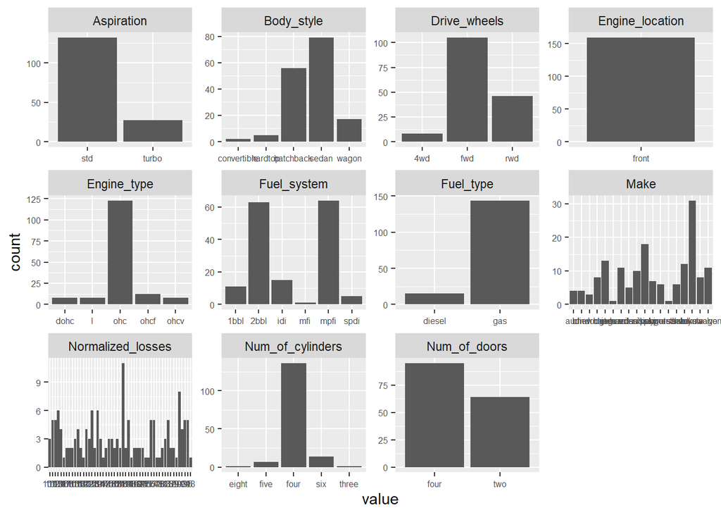

Podemos ver en la imagen, los registros de automóviles a gasolinas son mucho más que los registros de los automóviles a diésel eso nos da una idea de que están los datos están desbalanceados.

#### Análisis exploratorio de las variables de tipo entero.

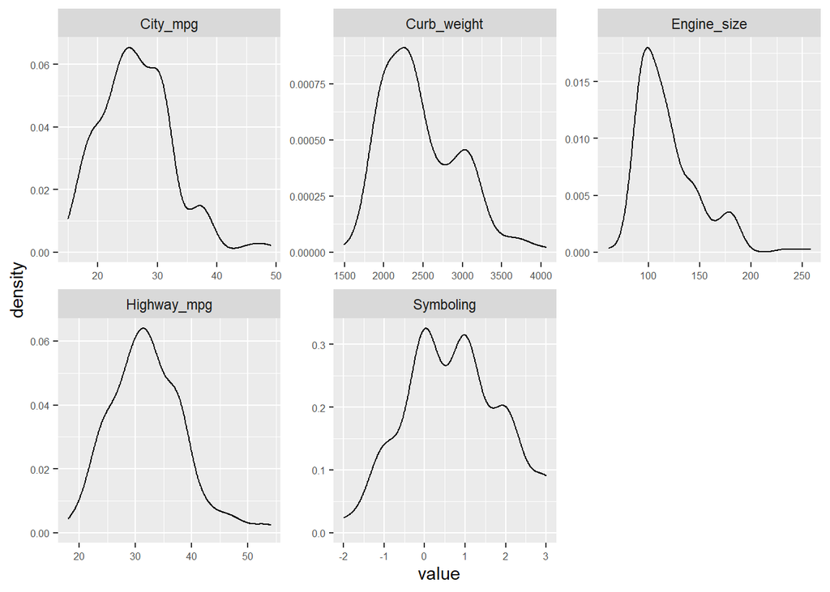

#### Análisis exploratorio de las variables de tipo double.

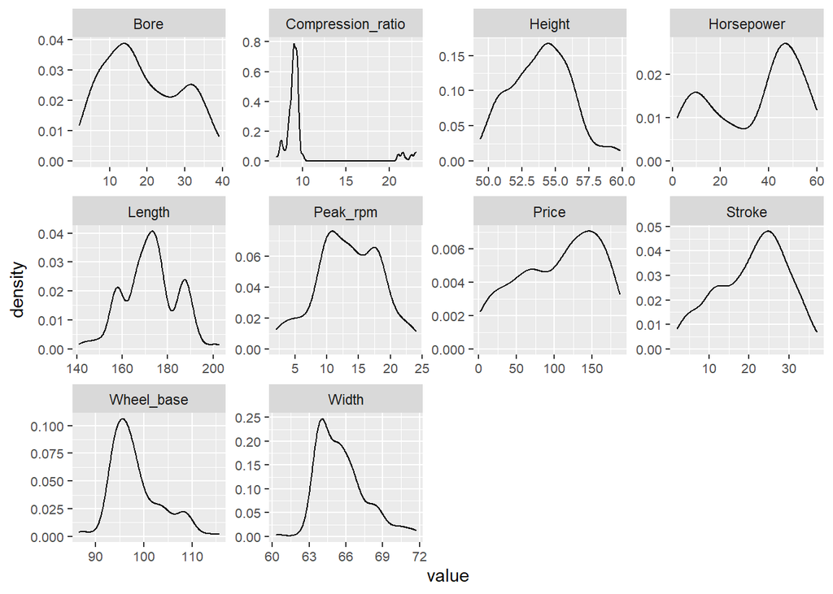

#### Análisis de correlaciones de las variables tipo integer.

```
##             Symboling Curb_weight Engine_size City_mpg Highway_mpg
## Symboling        1.00       -0.25       -0.11     0.09        0.15
## Curb_weight     -0.25        1.00        0.89    -0.76       -0.79
## Engine_size     -0.11        0.89        1.00    -0.70       -0.71
## City_mpg         0.09       -0.76       -0.70     1.00        0.97
## Highway_mpg      0.15       -0.79       -0.71     0.97        1.00
```

#### Análisis de correlaciones de las variables tipo double.

```
##                   Wheel_base Length Width Height  Bore Stroke Compression_ratio
## Wheel_base              1.00   0.87  0.81   0.56  0.57   0.19              0.29
## Length                  0.87   1.00  0.84   0.50  0.65   0.13              0.18
## Width                   0.81   0.84  1.00   0.29  0.56   0.22              0.26
## Height                  0.56   0.50  0.29   1.00  0.27  -0.09              0.23
## Bore                    0.57   0.65  0.56   0.27  1.00  -0.15              0.00
## Stroke                  0.19   0.13  0.22  -0.09 -0.15   1.00              0.28
## Compression_ratio       0.29   0.18  0.26   0.23  0.00   0.28              1.00
## Horsepower             -0.26  -0.37 -0.33   0.00 -0.27   0.01              0.02
## Peak_rpm               -0.29  -0.24 -0.23  -0.25 -0.33  -0.03             -0.43
## Price                  -0.42  -0.45 -0.44  -0.19 -0.36   0.03             -0.02
##                   Horsepower Peak_rpm Price
## Wheel_base             -0.26    -0.29 -0.42
## Length                 -0.37    -0.24 -0.45
## Width                  -0.33    -0.23 -0.44
## Height                  0.00    -0.25 -0.19
## Bore                   -0.27    -0.33 -0.36
## Stroke                  0.01    -0.03  0.03
## Compression_ratio       0.02    -0.43 -0.02
## Horsepower              1.00    -0.23  0.33
## Peak_rpm               -0.23     1.00  0.06
## Price                   0.33     0.06  1.00
```

#### zoom sobre el balanceo de la variable target.

```
##
## diesel    gas
##     15    144
```

De todo el análisis se puede concluir que:  
Se eliminaron valores perdidos y nulos, se muestra la media de cada una de las variables, los cuartiles, la mediana, el máximo y, en la última columna se muestra el histograma de la distribución de cada una de las variables, para tener una idea general de su comportamiento.  
A primera vista las variables predictoras (Compression_ratio, Horsepower), al parecer tienen valores atípicos las demás variables parecen tener un comportamiento normal.  
Hay 15 vehículos a disesel y 144 a gasolina, esto nos indica que la variable objetivo o target(Fuel_type) no esta correctamente balanceada.

#### Obtenemos un conjunto de entrenamiento con el 70% de los datos y un conjunto de prueba con el 30% de los datos

```r
    #rm(d_train)
    #rm(d_test)
    set.seed(1234)
    df<- na.omit(dfvehiculos)
    df$split = runif(nrow(df))
    train = df[df$split<0.7, -ncol(df)]
    test = df[df$split>=0.7, -ncol(df)]
```

#### Construcción del modelo

En primera instancia construimos un modelo consideramos todas las variables numéricas, ya que puede ser cualquier variable la que tenga mayor impacto y significancia en la probabilidad de comprar de un vehículo a gasolina, más adelante definiremos la o las variables que consideraremos adecuadas para el modelo definitivo.

```r
x<-c('Symboling','Wheel_base', 'Length', 'Width', 'Height', 'Curb_weight','Engine_size','Bore', 'Stroke', 'Compression_ratio', 'Horsepower', 'Peak_rpm','City_mpg', 'Highway_mpg', 'Price')
y<-"Fuel_type"
fmla <- paste(y,paste(x, collapse = "+"),sep = "~")
model <- glm(fmla,data=train,family=binomial(link="logit"))
```

#### Análisis del AIC de varios modelos

```
## Start:  AIC=32
## Fuel_type ~ Symboling + Wheel_base + Length + Width + Height +
##     Curb_weight + Engine_size + Bore + Stroke + Compression_ratio +
##     Horsepower + Peak_rpm + City_mpg + Highway_mpg + Price
##
##                     Df   Deviance AIC
## - Price              1 7.4400e-10  30
## - Bore               1 7.4400e-10  30
## - Width              1 7.4400e-10  30
## - Height             1 7.4410e-10  30
## - Wheel_base         1 7.4410e-10  30
## - Length             1 7.4420e-10  30
## - Highway_mpg        1 7.4420e-10  30
## - City_mpg           1 7.4440e-10  30
## - Engine_size        1 7.4470e-10  30
## - Symboling          1 7.4490e-10  30
## - Curb_weight        1 7.4690e-10  30
## - Peak_rpm           1 7.4730e-10  30
## - Stroke             1 7.5140e-10  30
## - Horsepower         1 7.7120e-10  30
## - Compression_ratio  1 6.5599e-09  30
## <none>                 7.4400e-10  32
##
## Step:  AIC=30
## Fuel_type ~ Symboling + Wheel_base + Length + Width + Height +
##     Curb_weight + Engine_size + Bore + Stroke + Compression_ratio +
##     Horsepower + Peak_rpm + City_mpg + Highway_mpg
##
##                     Df   Deviance AIC
## - Width              1 7.4400e-10  28
## - Bore               1 7.4400e-10  28
## - Height             1 7.4410e-10  28
## - Wheel_base         1 7.4410e-10  28
## - Length             1 7.4420e-10  28
## - Highway_mpg        1 7.4420e-10  28
## - City_mpg           1 7.4430e-10  28
## - Engine_size        1 7.4470e-10  28
## - Symboling          1 7.4490e-10  28
## - Curb_weight        1 7.4690e-10  28
## - Peak_rpm           1 7.4750e-10  28
```

[output cut: 276 more lines]

```
## + Peak_rpm           1    0.000  6.000
## + Engine_size        1    0.000  6.000
## + Curb_weight        1    0.000  6.000
## + Bore               1    0.000  6.000
## + Highway_mpg        1    0.000  6.000
## + City_mpg           1    0.000  6.000
## + Length             1    0.000  6.000
## + Wheel_base         1    0.000  6.000
## + Width              1    0.000  6.000
## + Stroke             1    0.000  6.000
## + Horsepower         1    0.000  6.000
## + Height             1    0.000  6.000
## + Symboling          1    0.000  6.000
## + Price              1    0.000  6.000
## - Compression_ratio  1   77.595 79.595
```

```
##
## Call:  glm(formula = Fuel_type ~ Compression_ratio, family = binomial(link = "logit"),
##     data = train)
##
## Coefficients:
##       (Intercept)  Compression_ratio
##            67.297             -4.366
##
## Degrees of Freedom: 117 Total (i.e. Null);  116 Residual
## Null Deviance:       77.59
## Residual Deviance: 8.265e-10     AIC: 4
```

#### Construcción del Modelo definitivo.

Para construir el modelo definitivo consideramos las variables “Aspiration”,“Bore”,“Horsepower”,“Peak_rpm”.

```r
x<-c("Aspiration","Bore","Horsepower","Peak_rpm")
y<-"Fuel_type"
fmla <- paste(y,paste(x, collapse = "+"),sep = "~")
model <- glm(fmla,data=train,family=binomial(link="logit"))
```

#### Interpretación y evaluación del modelo construido

Después de construir el modelo, su objetivo es utilizarlo para predecir la probabilidad de sé que se compre un vehículo a gasolina.  
Pasamos datos al método predict().  
Almacenamos las predicciones para los conjuntos de datos de entrenamiento y prueba añadiendo la columna pred en los respectivos data frame(Train, Test)

```r
train$pred<-predict(model,newdata=train,type="response")
test$pred<-predict(model,newdata=test,type="response")
```

Clasificamos las nuevas instancias en las categorías de positivo y negativo, validamos que el modelo asigne valores altos a las instancias positivas y valores bajos a las instancias negativas.

#### Construcción del grafico de predicciones

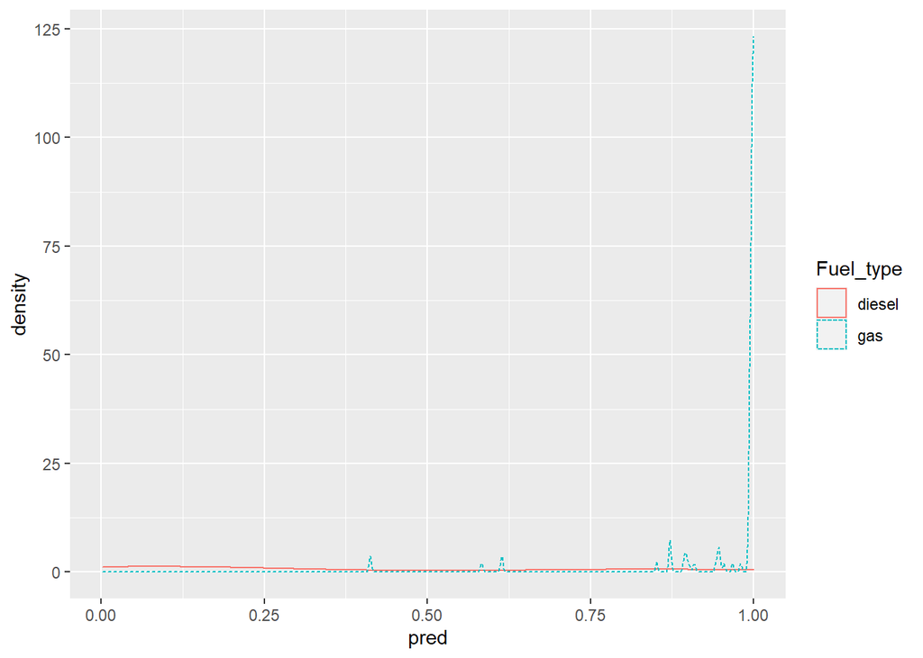

#### Evaluación de la calidad de la predicción con el conjunto de datos de test.

Para utilizar el modelo como clasificador tenemos que escoger el umbral (para todos los valores devueltos por el modelo) a partir del cual, las instancias se clasifican, como compras de vehículos a gasolina por encima del umbral, y por debajo se consideran como compras de vehículos a diésel.

#### Matríz de confusíon en los datos de test con umbral de 0.6

```
##        Fuel_type
## pred    diesel gas
##   FALSE      2   2
##   TRUE       1  36
```

#### cálculo del umbral de equilibrio con los siguientes valores (0.1,0.2,0.3,0.4,0.5,0.6,0.7,0.8,0.9)

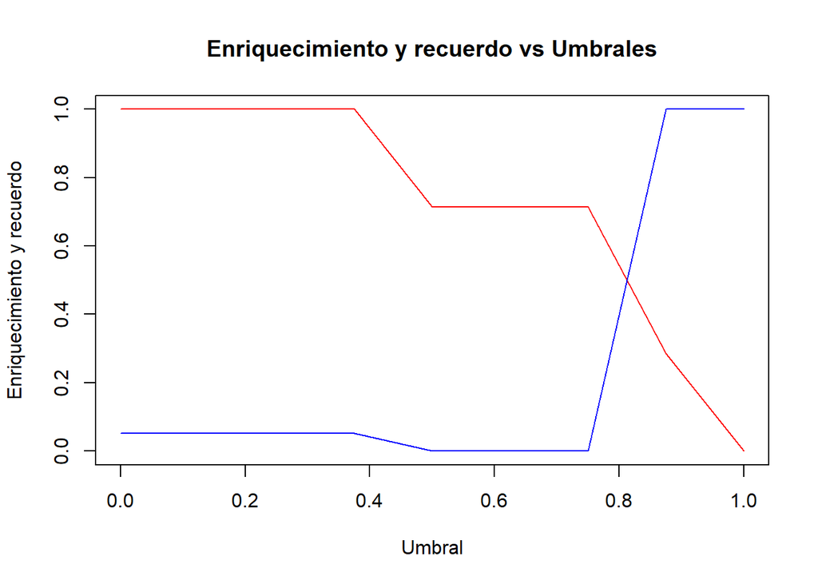

La gráfica nos muestra el punto de corte aproximadamente en el valor del umbal 0.8.

#### Realizamos el cálculo de la precision, recall y enrichmente con el umbral=0.8.

```
## [1] "Precision=  1"
```

```
## [1] "Enriquecimiento=  0.518987341772152"
```

```
## [1] "Recuerdo=  0.868421052631579"
```

#### Coeficientes del modelo

```
##     (Intercept) Aspirationturbo            Bore      Horsepower        Peak_rpm
##    -6.736794754    -5.768932007     0.265763794    -0.004490371     0.618842013
```

#### Resumen del modelo

```
##
## Call:
## glm(formula = fmla, family = binomial(link = "logit"), data = train)
##
## Deviance Residuals:
##      Min        1Q    Median        3Q       Max
## -2.03592   0.02150   0.04943   0.10595   1.33029
##
## Coefficients:
##                 Estimate Std. Error z value Pr(>|z|)
## (Intercept)     -6.73679    3.43321  -1.962  0.04973 *
## Aspirationturbo -5.76893    2.33249  -2.473  0.01339 *
## Bore             0.26576    0.13358   1.990  0.04664 *
## Horsepower      -0.00449    0.03463  -0.130  0.89684
## Peak_rpm         0.61884    0.18940   3.267  0.00109 **
## ---
## Signif. codes:  0 '***' 0.001 '**' 0.01 '*' 0.05 '.' 0.1 ' ' 1
##
## (Dispersion parameter for binomial family taken to be 1)
##
##     Null deviance: 77.595  on 117  degrees of freedom
## Residual deviance: 26.152  on 113  degrees of freedom
## AIC: 36.152
##
## Number of Fisher Scoring iterations: 8
```

#### Eficacia del modelo prediciendo la variable respuesta mediante el estadístico chi-cuadrado

```
## [1] 51.44241
```

Para saber la eficacia del modelo prediciendo la variable respuesta utilizamos el estadístico chi-cuadrado, que mide la diferencia entre el modelo en su estado actual y el modelo cuando sólo se incluyó la constante.

#### Probabilidad asociada al estadístico chi-cuadrado

Para calcular la probabilidad asociada al estadístico chi-cuadrado utilizamos la función pchisq(Chi, gl), cuyos argumentos son el estadístico chi-cuadrado y sus grados de libertad. La probabilidad que queremos es 1 menos el valor de la función pchisq( ).

```
## [1] 1.804178e-10
```

Como la probabilidad es menor que 0.05, podemos rechazar la hipótesis nula, de que el modelo es mejor prediciendo la variable resultado que si elegimos por azar. Por tanto, podemos decir que, en general, el modelo tiene una aportación significativa en la perdición sobre la compra de un vehículo a gasolina.

#### Resumen de la calidad del modelo

(Dispersion parameter for binomial family taken to be 1)

[output not shown]

El valor de AIC es bajo lo que implica un buen modelo en compración con otros.

#### Criterio de máxima verosimilitud

```
## [1] "Pseudo R-cuadrado =  0.662962691886625"
```

El estadístico log-likelihood es análogo a la suma de cuadrados residual en la regresión múltiple en el sentido de que es un indicador de cuánta información sin explicar queda en la variable respuesta tras haber ajustado el modelo. Grandes valores del log-likelihood indican un pobre ajuste del modelo, cuanto mayor sea este valor, más variabilidad sin explicar queda en el modelo. En nuestro caso el valor es bajo lo que indica que el modelo se ajusta adecuadamente a los datos ya que explica la mayor cantidad de información en la variable respuesta.

### d. Aplique el algoritmo k-medias y obtenga grupos de vehículos. Analice e interprete los grupos obtenidos.

Para aplicar el algaritmo K-medias consideraremos únicamente las variables numéricas del conjunto de datos vehículos, en base a lo analizado en los literales anteriores.

#### Definimos el conjunto de datos con las variables seleccionadas

```r
dfnew<-dfvehiculos[,c('Symboling','Wheel_base', 'Length', 'Width', 'Height', 'Curb_weight','Engine_size','Bore', 'Stroke', 'Compression_ratio', 'Horsepower', 'Peak_rpm',     'City_mpg', 'Highway_mpg', 'Price')]
```

#### Muestra de 10 observaciones seleccionadas

```
##    Symboling Wheel_base Length Width Height Curb_weight Engine_size Bore Stroke
## 4          2       99.8  176.6  66.2   54.3        2337         109   15     26
## 5          2       99.4  176.6  66.4   54.3        2824         136   15     26
## 7          1      105.8  192.7  71.4   55.7        2844         136   15     26
## 9          1      105.8  192.7  71.4   55.9        3086         131   12     26
## 11         2      101.2  176.8  64.8   54.3        2395         108   26      8
## 12         0      101.2  176.8  64.8   54.3        2395         108   26      8
## 13         0      101.2  176.8  64.8   54.3        2710         164   18     19
## 14         0      101.2  176.8  64.8   54.3        2765         164   18     19
## 19         2       88.4  141.1  60.3   53.2        1488          61    4     11
## 20         1       94.5  155.9  63.6   52.0        1874          90    9     15
##    Compression_ratio Horsepower Peak_rpm City_mpg Highway_mpg Price
## 4               10.0          4       18       24          30    38
## 5                8.0         10       18       18          22    63
## 7                8.5          6       18       19          25    65
## 9                8.3         17       18       17          20    83
## 11               8.8          3       21       23          29    51
## 12               8.8          3       21       23          29    60
## 13               9.0         13        4       21          28    77
## 14               9.0         13        4       21          28    78
## 19               9.5         36       13       47          53   103
## 20               9.6         46       17       38          43   113
```

#### Resumen estadístico de las variables seleccionadas

```
##    Symboling         Wheel_base         Length          Width
##  Min.   :-2.0000   Min.   : 86.60   Min.   :141.1   Min.   :60.30
##  1st Qu.: 0.0000   1st Qu.: 94.50   1st Qu.:165.7   1st Qu.:64.00
##  Median : 1.0000   Median : 96.90   Median :172.4   Median :65.40
##  Mean   : 0.7358   Mean   : 98.26   Mean   :172.4   Mean   :65.61
##  3rd Qu.: 2.0000   3rd Qu.:100.80   3rd Qu.:177.8   3rd Qu.:66.50
##  Max.   : 3.0000   Max.   :115.60   Max.   :202.6   Max.   :71.70
##      Height       Curb_weight    Engine_size         Bore           Stroke
##  Min.   :49.40   Min.   :1488   Min.   : 61.0   Min.   : 2.00   Min.   : 2.00
##  1st Qu.:52.25   1st Qu.:2066   1st Qu.: 97.0   1st Qu.:10.00   1st Qu.:14.50
##  Median :54.10   Median :2340   Median :110.0   Median :17.00   Median :22.00
##  Mean   :53.90   Mean   :2461   Mean   :119.2   Mean   :18.85   Mean   :20.79
##  3rd Qu.:55.50   3rd Qu.:2810   3rd Qu.:135.0   3rd Qu.:27.50   3rd Qu.:27.00
##  Max.   :59.80   Max.   :4066   Max.   :258.0   Max.   :39.00   Max.   :37.00
##  Compression_ratio   Horsepower       Peak_rpm        City_mpg
##  Min.   : 7.00     Min.   : 2.00   Min.   : 2.00   Min.   :15.00
##  1st Qu.: 8.70     1st Qu.:14.00   1st Qu.:10.00   1st Qu.:23.00
##  Median : 9.00     Median :44.00   Median :14.00   Median :26.00
##  Mean   :10.16     Mean   :34.51   Mean   :13.36   Mean   :26.52
##  3rd Qu.: 9.40     3rd Qu.:49.00   3rd Qu.:18.00   3rd Qu.:31.00
##  Max.   :23.00     Max.   :60.00   Max.   :24.00   Max.   :49.00
##   Highway_mpg        Price
##  Min.   :18.00   Min.   :  2.0
##  1st Qu.:28.00   1st Qu.: 63.5
##  Median :32.00   Median :114.0
##  Mean   :32.08   Mean   :105.2
##  3rd Qu.:37.00   3rd Qu.:150.0
##  Max.   :54.00   Max.   :187.0
```

#### Re-escalar las variables seleccionadas para que tengan media 0 y desviación típica 1

```r
num.vars<-colnames(dfnew)
dfvehiculosscale<-scale(dfvehiculos[,num.vars])
```

#### Muestra de las variables re-escaladas para aplicar el algoritmo K-medias

```
##     Symboling Wheel_base     Length      Width     Height Curb_weight
## 4   1.0595642  0.2972180  0.3632821  0.3041522  0.1765849  -0.2575798
## 5   1.0595642  0.2198099  0.3632821  0.4068278  0.1765849   0.7529166
## 7   0.2214015  1.4583399  1.7604662  2.9737177  0.7936617   0.7944155
## 9   0.2214015  1.4583399  1.7604662  2.9737177  0.8818155   1.2965513
## 11  1.0595642  0.5681465  0.3806384 -0.4145769  0.1765849  -0.1372332
## 12 -0.6167613  0.5681465  0.3806384 -0.4145769  0.1765849  -0.1372332
## 13 -0.6167613  0.5681465  0.3806384 -0.4145769  0.1765849   0.5163733
## 14 -0.6167613  0.5681465  0.3806384 -0.4145769  0.1765849   0.6304951
## 19  1.0595642 -1.9089137 -2.7174656 -2.7247778 -0.3082612  -2.0192051
## 20  0.2214015 -0.7284397 -1.4330975 -1.0306305 -0.8371842  -1.2182777
##    Engine_size        Bore     Stroke Compression_ratio  Horsepower   Peak_rpm
## 4   -0.3357239 -0.38651898  0.6150644       -0.04142772 -1.64553777  0.9247309
## 5    0.5506615 -0.38651898  0.6150644       -0.55563599 -1.32192552  0.9247309
## 7    0.5506615 -0.38651898  0.6150644       -0.42708392 -1.53766702  0.9247309
```

[output cut: 18 more lines]

#### Aplicamos el algoritmo de k-medias para encontrar los grupos de vehículos

Primeramente almacenamos la media y la desviación típica de las variables, para después poder reconstruir el conjunto de datos original.

```r
pcenter<- attr(dfvehiculosscale,"scaled:center")
pscale<- attr(dfvehiculosscale,"scaled:scale")
```

#### Inicio del Agrupamiento

```r
k<-10 #Numero de grupos
pclusters<-kmeans(dfvehiculosscale,k,nstart = 10, iter.max = 100)
```

#### Resumen estaístico del Agrupamiento (k-medias)

```
##              Length Class  Mode
## cluster      159    -none- numeric
## centers      150    -none- numeric
## totss          1    -none- numeric
## withinss      10    -none- numeric
## tot.withinss   1    -none- numeric
## betweenss      1    -none- numeric
## size          10    -none- numeric
## iter           1    -none- numeric
## ifault         1    -none- numeric
```

#### Centroides con valores escaldos

```
##     Symboling Wheel_base     Length      Width      Height Curb_weight
## 1   0.3316860 -0.9092284 -1.1439777 -0.9184979 -0.57620243 -1.08504462
## 2   0.3610953 -0.3801031 -0.3107219 -0.3889080  0.29412331 -0.46887803
## 3  -1.0957114  1.4058130  1.2943249  1.2062307  0.91749681  1.18549251
## 4   0.8500235  0.1762678  0.7451212  0.2014766  0.59531556  0.35452788
## 5  -0.9892780  2.2302710  1.6264368  2.0439331  0.96507190  2.15880471
## 6  -1.0036056  0.5770782  0.3379151  0.1738332  0.68516465  0.04344628
## 7   0.2214015 -0.5683456 -0.4201193 -0.4379123 -0.87725408 -0.35321577
## 8   1.4187768 -0.1478787  0.3267098  0.7075206 -1.17405772  0.91209428
## 9  -0.2638506 -0.4880671 -0.3812129 -0.5821003  0.13018812 -0.39550883
## 10  0.1690163 -0.2990665 -0.1579501 -0.3247358 -0.01625163 -0.40425225
##    Engine_size        Bore     Stroke Compression_ratio Horsepower   Peak_rpm
## 1  -0.90418546 -1.03924345 -0.1277865        -0.2145671  0.5246514  0.4109256
## 2  -0.55458447 -0.80493210  0.5953794         3.2109396  0.2422004 -0.9679602
## 3   0.83049039  0.99065790 -0.3016957        -0.3756631 -0.6618593  0.3839620
```

[output cut: 18 more lines]

#### Tamaño de cada grupo

```
##  [1] 38  6 21 12  9 13 11 14 19 16
```

#### Vector con las etiquetas de grupo para cada observación(fila en los datos)

```
##   4   5   7   9  11  12  13  14  19  20  21  22  23  24  25  26  27  29  30  31
##   4   4   3   3   4   4   6   6   1   1   1   1   1   7   1   1   1   6   8   1
##  32  33  34  35  36  37  38  39  40  41  42  43  48  51  52  53  54  55  60  61
##   1   1   1   1  10  10  10  10  10  10   7   7   5   1   1   1   1   1  10   6
##  62  63  65  66  68  69  70  71  73  77  78  79  80  81  82  86  87  88  89  90
##   6   6   6   3   5   5   5   5   8   1   1   1   7   7  10  10  10   7   7   1
##  91  92  93  94  95  96  97  98  99 100 101 102 103 104 105 106 107 108 109 112
##   2   1   1   1   1   1   1   1   1  10  10   3   3   3   8   8   8   3   5   3
## 113 116 117 118 119 120 121 122 123 124 126 133 134 135 136 137 138 139 140 141
##   5   3   5   3   1   7   1   1   1   6   8   4   4   4   4   4   4   9   9   9
## 142 143 144 145 146 147 148 149 150 151 152 153 154 155 156 157 158 159 160 161
##   9   9   9   9   4   9   9   9   4   1   1   1   9   9   9   9   9   2   2   1
## 162 163 164 165 166 167 168 169 170 171 172 173 174 175 176 177 178 179 180 181
##   9   9   9   9   7   7   8   8   8   8   8   8   6   6   6   6   6   8   8   3
## 183 184 185 186 187 188 189 191 195 196 197 198 199 200 201 202 203 204 205
##   2  10   2  10  10   2   7  10   3   3   3   3   3   3   3   3   3   5   3
```

#### Detalle de grupos en el conjunto de datos de los vehículos

```
## [1] "cluster 1"
##     Symboling Wheel_base Length Width Height Curb_weight Engine_size Bore
## 19          2       88.4  141.1  60.3   53.2        1488          61    4
## 20          1       94.5  155.9  63.6   52.0        1874          90    9
## 21          0       94.5  158.8  63.6   52.0        1909          90    9
## 22          1       93.7  157.3  63.8   50.8        1876          90    6
## 23          1       93.7  157.3  63.8   50.8        1876          90    6
## 25          1       93.7  157.3  63.8   50.6        1967          90    6
## 26          1       93.7  157.3  63.8   50.6        1989          90    6
## 27          1       93.7  157.3  63.8   50.6        1989          90    6
## 31          2       86.6  144.6  63.9   50.8        1713          92    4
## 32          2       86.6  144.6  63.9   50.8        1819          92    4
## 33          1       93.7  150.0  64.0   52.6        1837          79    4
## 34          1       93.7  150.0  64.0   52.6        1940          92    4
## 35          1       93.7  150.0  64.0   52.6        1956          92    4
```

[output cut: 333 more lines]

Como podemos ver en la imagen anterior el algoritmo de k-medias a clasificado los datos en 10 grupos que son identificados como: “Cluster 1”, “Cluster 2”…… : “Cluster 10”, según lo indicado en el valor de k.

#### Determinamos el número óptimo del número de grupos(K)

Para determinar el número óptimo de grupos, primeramente, definimos el rango de números de grupos, para esta práctica decidimos realizarla con un rango de 2-10 números de grupos.  
Para cada valor de k que va desde k=2 a k=10, vamos calculando la suma total del valor de WSS y el valor del índice de CALINSKI HARABASZ de agrupamiento, este cálculo lo realizamos con las funciones implementadas en Rstudio.

#### Matríz para realizar la gráfica que permite determinar el valor optimo de K

```
##    k       wss  chindex
## 1  2 1566.7243 80.49552
## 2  3 1375.9164 56.35409
## 3  4 1217.5938 48.90053
## 4  5 1115.5076 43.29684
## 5  6  989.1147 42.72011
## 6  7  899.7911 41.39326
## 7  8  845.0500 38.92710
## 8  9  781.3002 38.12634
## 9 10  720.7882 37.88022
```

#### Gráfica para determinar el valor de K

Con los datos obtenidos anteriormente de realiza la gráfica del número de grupos con respecto a la suma total de WSS para cada número de grupos.

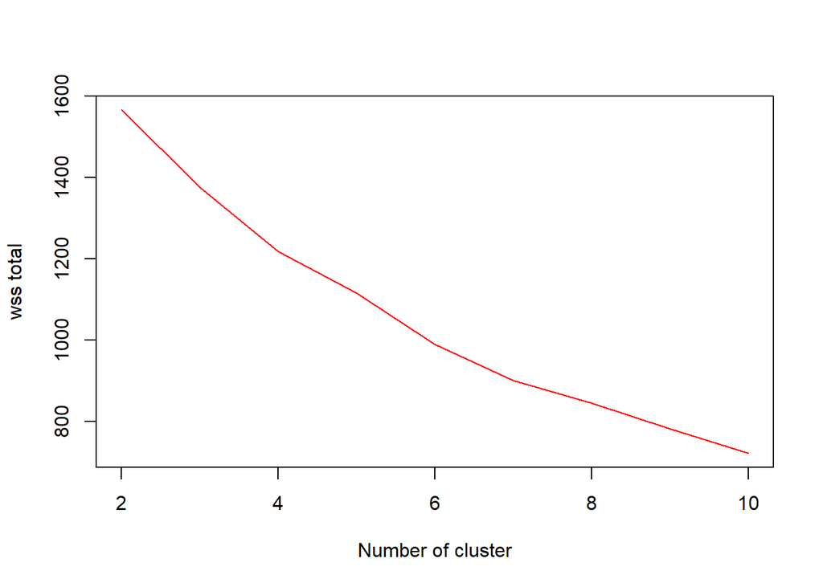

En la gráfica no se puede apreciar claramente el punto de quiebre, en el qué el valor de la suma del total de WSS comience a relentizar considerablemente en su decrecimiento, se puede considerar el decrecimiento con el valor de K=5 o k=6.

#### Refinado de la gráfica para determinar el valor de K

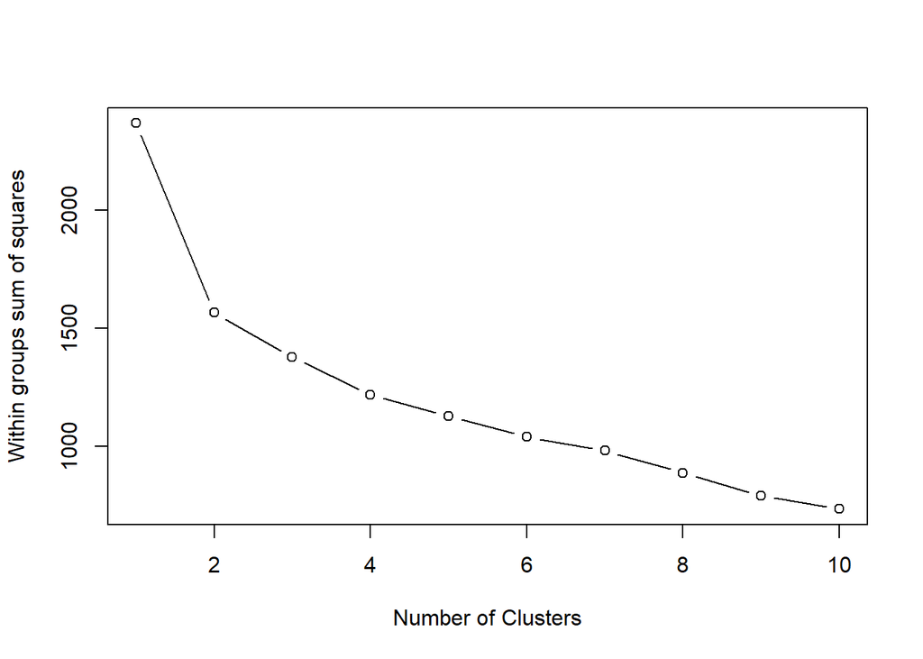

```
##  [1] 2370.0000 1566.7258 1377.4101 1217.5938 1126.6777 1039.0915  979.9152
##  [8]  886.5150  788.7801  733.0203
```

#### Gráfica CALINSKI HARABASZ para determinar el valor de K

Para comprobar lo obtenido en el análisis anterior, realizamos la gráfica del número de grupos con respecto al índice de CALINSKI HARABASZ de agrupamiento

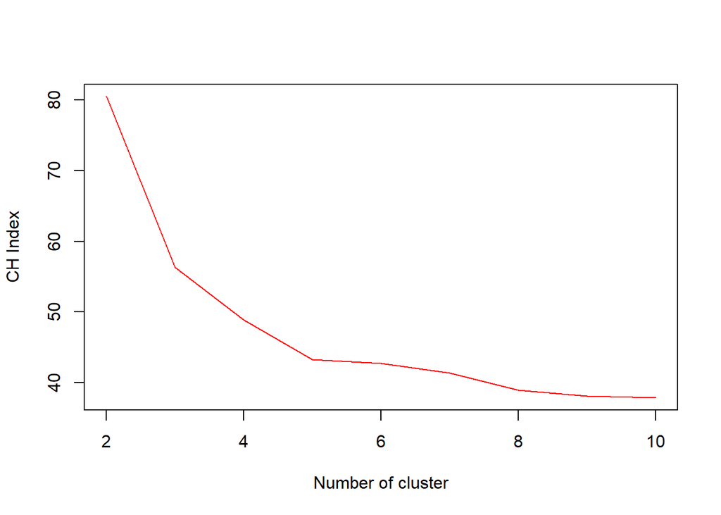

#### Aplicamos el algoritmo k-medias con el número óptimo de grupos K=5

```r
  k<-5 #Numero de grupos
  pclusters<-kmeans(dfvehiculosscale,k,nstart = 10, iter.max = 100)#Ejecutamos el algoritmo de agrupamiento
```

#### Resumen estadístico del agrupamiento

```r
  summary(pclusters)
```

```
##              Length Class  Mode
## cluster      159    -none- numeric
## centers       75    -none- numeric
## totss          1    -none- numeric
## withinss       5    -none- numeric
## tot.withinss   1    -none- numeric
## betweenss      1    -none- numeric
## size           5    -none- numeric
## iter           1    -none- numeric
## ifault         1    -none- numeric
```

#### Enfoque en el Output del agrupamiento

```
## K-means clustering with 5 clusters of sizes 38, 33, 57, 9, 22
##
## Cluster means:
##    Symboling Wheel_base     Length      Width     Height Curb_weight
## 1 -0.4844198 -0.0776003 -0.0117059 -0.1740999  0.3354937  -0.2251452
## 2 -0.4897669  0.9774713  1.0956664  0.7941948  0.8003400   0.9030669
## 3  0.2949245 -0.8038108 -0.9765044 -0.8459946 -0.4629170  -0.9241821
## 4 -0.9892780  2.2302710  1.6264368  2.0439331  0.9650719   2.1588047
## 5  1.2119574 -0.1619529  0.2413933  0.4651662 -0.9754254   0.5456111
##   Engine_size       Bore      Stroke Compression_ratio Horsepower   Peak_rpm
## 1  -0.2363727  0.1657863 -0.01589268        -0.2565833  0.9021990 -0.4174545
## 2   0.5834906  0.8215538 -0.63404036        -0.3615613 -0.9018834  0.2787406
## 3  -0.8212488 -0.9009469 -0.10810152         0.1110756  0.3396625  0.3235437
## 4   1.8893588  0.9524030  1.37621895         2.5324703 -0.2611965 -1.6652674
## 5   0.8879058  0.4259632  0.69559407        -0.3382661 -0.9787004  0.1459202
```

[output cut: 33 more lines]

Interpretacion de los datos mostrados.  
Hay 5 clúster(grupos) de 38, 33, 57, 9, y 22 datos cada uno para un total de 159 registros.  
El algoritmo computa la media óptima para hallar los centroides, los cuales, muestra en Cluster Means, cuando detecta estos, en este caso son 5, por k=5.  
En Clustering vector, indica el pronóstico para cada registro testeado con el algoritmo.  
Within cluster sum of squares by cluster:  
between_SS / total_SS, es una medida de calidad e indica que tanto están separados los grupos de manera inter-cluster en relación al agrupamiento intra-cluster, mientras, se esté más cercano al 100%, mayor será la calidad del modelo.  
288.44441 220.94533 354.70786 68.17559 165.42361, es la inercia intra-clúster de cada grupo.  
Available components:Son Elementos disponibles del modelo, los cuales, se explican a continuación. 1. Cluster: La categorización asignada a cada observación del dataset en función a su cercanía a estos centros.  
2. Centers: Los centroides.  
3. Totss: Inercia total del conjunto de datos.  
4. Withinss: Inercia intra-clases de cada uno de los grupos.  
5. Tot.withinss: Inercia intra-clases total.  
6. Betweenss: Inercia inter-clases.  
7. Size: El tamaño de cada grupo.  
8. Iter : Número de iteraciones empleado.

#### Centroides con valores escaldos y k=5

```
##    Symboling Wheel_base     Length      Width     Height Curb_weight
## 1 -0.4844198 -0.0776003 -0.0117059 -0.1740999  0.3354937  -0.2251452
## 2 -0.4897669  0.9774713  1.0956664  0.7941948  0.8003400   0.9030669
## 3  0.2949245 -0.8038108 -0.9765044 -0.8459946 -0.4629170  -0.9241821
## 4 -0.9892780  2.2302710  1.6264368  2.0439331  0.9650719   2.1588047
## 5  1.2119574 -0.1619529  0.2413933  0.4651662 -0.9754254   0.5456111
##   Engine_size       Bore      Stroke Compression_ratio Horsepower   Peak_rpm
## 1  -0.2363727  0.1657863 -0.01589268        -0.2565833  0.9021990 -0.4174545
## 2   0.5834906  0.8215538 -0.63404036        -0.3615613 -0.9018834  0.2787406
## 3  -0.8212488 -0.9009469 -0.10810152         0.1110756  0.3396625  0.3235437
## 4   1.8893588  0.9524030  1.37621895         2.5324703 -0.2611965 -1.6652674
## 5   0.8879058  0.4259632  0.69559407        -0.3382661 -0.9787004  0.1459202
##     City_mpg Highway_mpg      Price
## 1  0.0222862  0.04030603  0.4113061
## 2 -1.0348932 -0.98848190 -0.9936759
## 3  0.9559994  0.93797998  0.5023176
## 4 -0.4683089 -0.75234505 -0.5712440
## 5 -0.7714812 -0.70934000 -0.2876925
```

#### Número de puntos de cada grupo

```
## [1] 38 33 57  9 22
```

#### Vector con las etiquetas de grupo para cada observación

```
##   4   5   7   9  11  12  13  14  19  20  21  22  23  24  25  26  27  29  30  31
##   5   5   2   2   2   2   2   2   3   3   3   3   3   3   3   3   3   1   5   3
##  32  33  34  35  36  37  38  39  40  41  42  43  48  51  52  53  54  55  60  61
##   3   3   3   3   3   3   1   1   1   1   5   5   4   3   3   3   3   3   1   1
##  62  63  65  66  68  69  70  71  73  77  78  79  80  81  82  86  87  88  89  90
##   1   1   1   2   4   4   4   4   5   3   3   3   3   5   5   1   1   5   1   3
##  91  92  93  94  95  96  97  98  99 100 101 102 103 104 105 106 107 108 109 112
##   3   3   3   3   3   3   3   3   3   1   1   2   2   2   5   5   5   2   4   2
## 113 116 117 118 119 120 121 122 123 124 126 133 134 135 136 137 138 139 140 141
##   4   2   4   2   3   3   3   3   3   1   5   2   2   2   2   2   2   3   1   1
## 142 143 144 145 146 147 148 149 150 151 152 153 154 155 156 157 158 159 160 161
##   1   1   1   1   2   1   1   1   2   3   3   3   1   1   1   3   3   3   3   3
## 162 163 164 165 166 167 168 169 170 171 172 173 174 175 176 177 178 179 180 181
##   1   1   3   3   3   3   5   5   5   5   5   5   1   1   1   1   1   5   5   2
## 183 184 185 186 187 188 189 191 195 196 197 198 199 200 201 202 203 204 205
##   3   1   3   1   1   3   5   3   2   2   2   2   2   2   2   2   2   4   2
```

#### Grupos en el conjunto de datos de vehículos

```
## [1] "cluster 1"
##     Symboling Wheel_base Length Width Height Curb_weight Engine_size Bore
## 30          3       95.9  173.2  66.3   50.2        2811         156   30
## 82          3       96.3  173.0  65.4   49.4        2328         122   21
## 105         3       91.3  170.7  67.9   49.7        3071         181   23
## 106         3       91.3  170.7  67.9   49.7        3139         181   23
## 107         1       99.2  178.5  67.9   49.7        3139         181   23
## 126         3       94.5  168.9  68.3   50.2        2778         151   39
## 168         2       98.4  176.2  65.6   52.0        2540         146   32
## 169         2       98.4  176.2  65.6   52.0        2536         146   32
## 170         2       98.4  176.2  65.6   52.0        2551         146   32
## 171         2       98.4  176.2  65.6   52.0        2679         146   32
## 172         2       98.4  176.2  65.6   52.0        2714         146   32
## 173         2       98.4  176.2  65.6   53.0        2975         146   32
## 179         3      102.9  183.5  67.7   52.0        2976         171   17
```

[output cut: 192 more lines]

Como podemos ver en el detalle de los grupos el agrupamiento de k-medias a clasificado los datos en cinco grupos de acuerdo con el valor óptimo k=5.

#### Gráfica de cómo están distribuidos y clasificados los grupos.

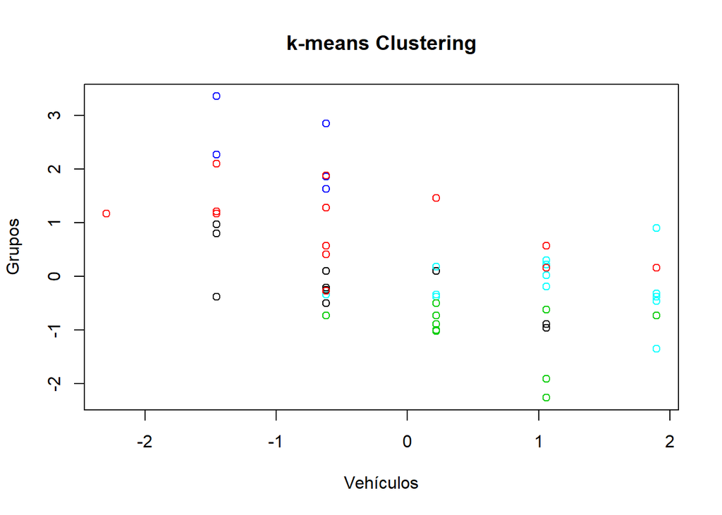